# Horse Colic Dataset

Este trabalho tem como objetivo analisar alguns algoritmos de *data mining* a fim de classificar resultados. O dados utilizados foram disponibilizados pela [UCI Machine Learning Database](http://archiove.ics.uci.edu/ml/datasets/Horse+Colic) e trata-se de dados de procedimentos gastrointestinal em cavalos.

O *dataset* contém dados como idade, temperatura, respiração, contagem de proteínas, entre outras informações de atendimentos veterinários onde há 3 possíveis resultados. O cavalo pode ter **sobrevivido** ao procedimento, pode ter sido proposto a **eutanasia** ou ter ocorrido o **falecimento**. Nesse exemplo iremos inferir a partir dos parametros de atendimento a classe em que o cavalo se insere.

[Repositório](https://github.com/jfalves/horse_colic_dataset) com o código do projeto.

### Análise inicial

É muito importante conhecer os dados antes de tentar aplicar qualquer tipo de inferência, ou seja, fazer uma análise descritiva dos dados. Essa é a etapa mais importante do processo de *data science*.

|  | surgery | age | hospital_number | rectal_temp | pulse | respiratory_rate | temp_of_extremities | peripheral_pulse | mucous_membrane | capillary_refill_time | pain | peristalsis | abdominal_distention | nasogastric_tube | nasogastric_reflux | nasogastric_reflux_ph | rectal_exam_feces | abdomen | packed_cell_volume | total_protein | abdomo_appearance | abdomo_protein | outcome | surgical_lesion | lesion_1 | lesion_2 | lesion_3 | cp_data |
| --- | --- | --- | --- | --- | --- | --- | --- | --- | --- | --- | --- | --- | --- | --- | --- | --- | --- | --- | --- | --- | --- | --- | --- | --- | --- | --- | --- | --- |
| 1 | no | adult | 530101 | 38.5 | 66 | 28 | cool | reduced | NA | more_3_sec | extreme_pain | absent | severe | NA | NA | NA | decreased | distend_large | 45 | 8.4 | NA | NA | died | no | 11300 | 0 | 0 | no |
| 2 | yes | adult | 534817 | 39.2 | 88 | 20 | NA | NA | pale_cyanotic | less_3_sec | mild_pain | absent | slight | NA | NA | NA | absent | other | 50 | 85.0 | cloudy | 2.0 | euthanized | no | 2208 | 0 | 0 | no |
| 3 | no | adult | 530334 | 38.3 | 40 | 24 | normal | normal | pale_pink | less_3_sec | mild_pain | hypomotile | none | NA | NA | NA | normal | normal | 33 | 6.7 | NA | NA | lived | no | 0 | 0 | 0 | yes |
| 4 | yes | young | 5290409 | 39.1 | 164 | 84 | cold | normal | dark_cyanotic | more_3_sec | depressed | absent | severe | none | less_1_liter | 5 | decreased | NA | 48 | 7.2 | serosanguious | 5.3 | died | yes | 2208 | 0 | 0 | yes |
| 5 | no | adult | 530255 | 37.3 | 104 | 35 | NA | NA | dark_cyanotic | more_3_sec | NA | NA | NA | NA | NA | NA | NA | NA | 74 | 7.4 | NA | NA | died | no | 4300 | 0 | 0 | no |
| 6 | no | adult | 528355 | NA | NA | NA | warm | normal | pale_pink | less_3_sec | depressed | hypomotile | slight | slight | none | NA | decreased | firm | NA | NA | NA | NA | lived | no | 0 | 0 | 0 | no |
| 7 | yes | adult | 526802 | 37.9 | 48 | 16 | normal | normal | normal_pink | less_3_sec | mild_pain | hypomotile | moderate | none | none | NA | decreased | distend_large | 37 | 7.0 | NA | NA | lived | yes | 3124 | 0 | 0 | no |
| 8 | yes | adult | 529607 | NA | 60 | NA | cool | NA | NA | less_3_sec | NA | absent | slight | slight | none | NA | decreased | distend_small | 44 | 8.3 | NA | NA | died | yes | 2208 | 0 | 0 | no |
| 9 | no | adult | 530051 | NA | 80 | 36 | cool | absent | pale_pink | less_3_sec | severe_pain | absent | severe | slight | none | NA | decreased | distend_large | 38 | 6.2 | NA | NA | euthanized | yes | 3205 | 0 | 0 | no |
| 10 | no | young | 5299629 | 38.3 | 90 | NA | normal | NA | normal_pink | less_3_sec | extreme_pain | hypomotile | none | slight | none | NA | decreased | NA | 40 | 6.2 | clear | 2.2 | lived | no | 0 | 0 | 0 | yes |

Olhando para os dados é possível classificar-los em 4 categorias baseadas nas informações que elas evidenciam sobre o problema, a saber, as categorias são: id, categórico, discreto e a classe a ser predita.

#### 1. Dados Categóricos e a Classe

Os dados categóricos são aqueles que dão informações qualitativas como por exemplo, o atributo **age** que corresponde aos valores *adult* e *young*. Nesse caso em específico além de categorico o dado é binomial, indicando que só há duas possíveis classificações para ele. Os dados categóricos do problema são:

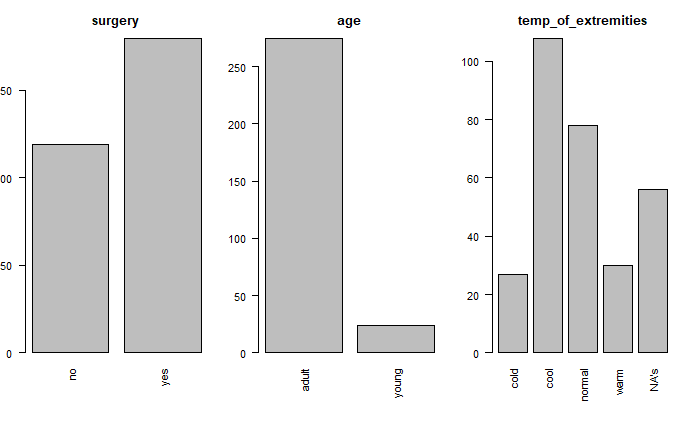

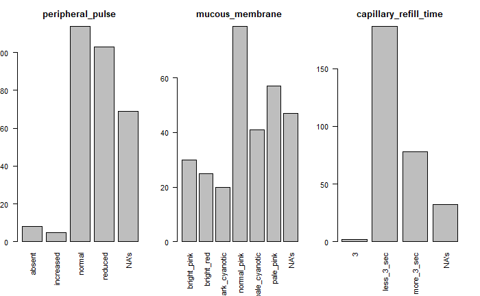

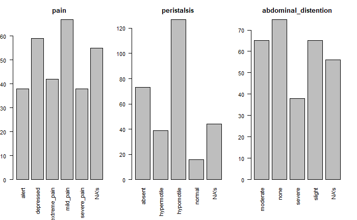

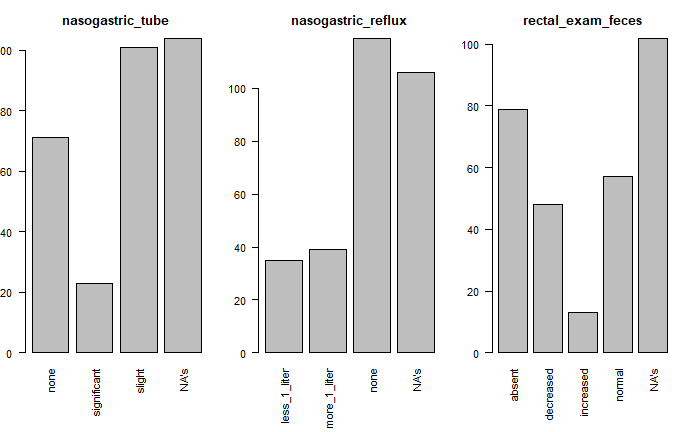

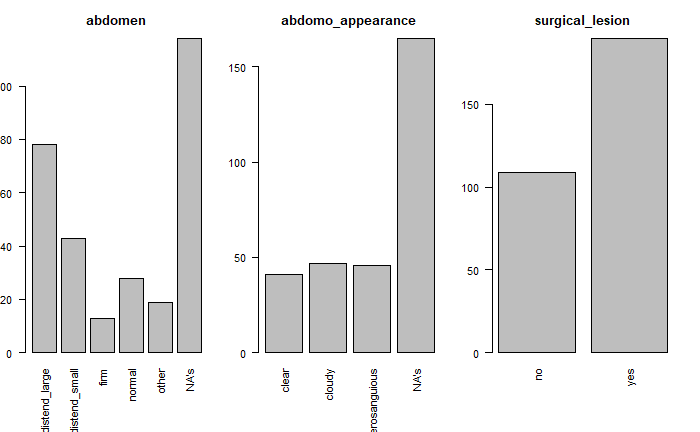

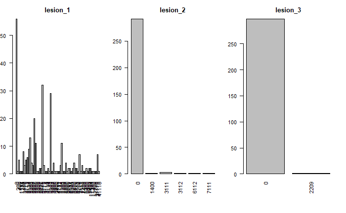

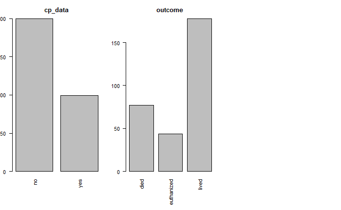

Já com essa leitura podemos identificar alguns problemas como:

- Quantidade de valores Nulos em determinados parametros;
- Desbalanceamento entre as 3 classes de inferência;
- Para os parametros **lesion_1**, **lesion_2** e **lesion_3**, apesar de numéricos, representam categorias da lesão;

#### 2. Dados Discretos

Os dados discretos ou no caso discretizados, pois derivam de dados contínuos, são representações númericas de algum parametro, como por exemplo, **pulse** que representa o pulso do cavalo em um determinado momento do procedimento médico. Os dados discretos do problema são:

```
          rectal_temp                 pulse      respiratory_rate nasogastric_reflux_ph    packed_cell_volume
                   60                    24                    58                   246                    29
        total_protein        abdomo_protein
                   33                   198
```

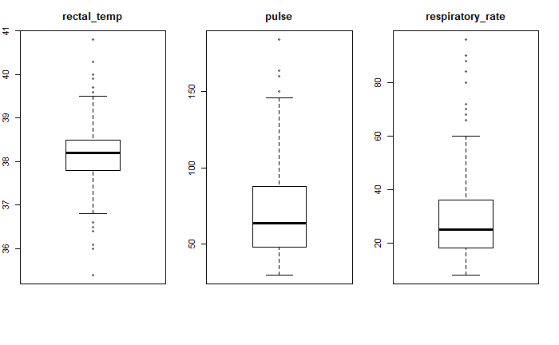

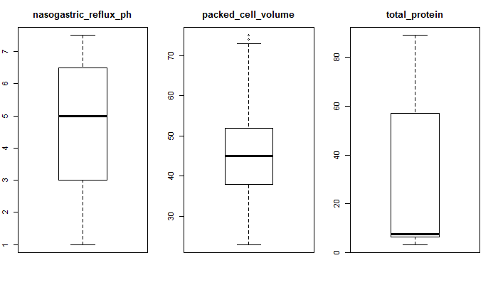

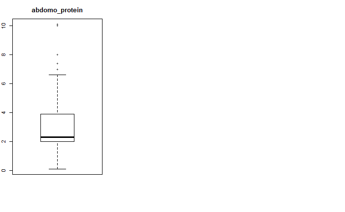

Com essa preliminar podemos observar que:

- os dados contêm alguns *outliers*, principalmente em **rectal_temp** e **respiratory_rate**;
- algumas distribuições estão inclinadas positivamente, principalmente **total_protein**;
- as colunas **abdomo_protein** e **nasogastric_reflux_ph** contém alta concentração de nulos;

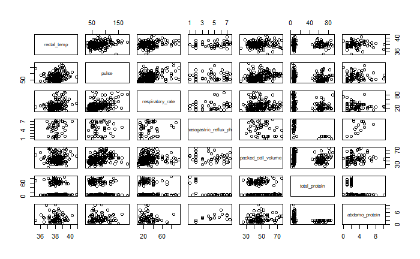

|  | rectal_temp | pulse | respiratory_rate | nasogastric_reflux_ph | packed_cell_volume | total_protein | abdomo_protein |
| --- | --- | --- | --- | --- | --- | --- | --- |
| rectal_temp | 1.000000000 | 0.23545465 | 0.230844398 | 0.25270324 | 0.06208520 | 0.007778701 | 0.119354025 |
| pulse | 0.235454648 | 1.00000000 | 0.471029518 | -0.01242372 | 0.47301810 | -0.062789408 | 0.102805621 |
| respiratory_rate | 0.230844398 | 0.47102952 | 1.000000000 | 0.13336861 | 0.20655924 | -0.057879427 | -0.005893767 |
| nasogastric_reflux_ph | 0.252703237 | -0.01242372 | 0.133368612 | 1.00000000 | -0.07301921 | -0.300861820 | 0.534064581 |
| packed_cell_volume | 0.062085200 | 0.47301810 | 0.206559244 | -0.07301921 | 1.00000000 | 0.158191167 | 0.195677992 |
| total_protein | 0.007778701 | -0.06278941 | -0.057879427 | -0.30086182 | 0.15819117 | 1.000000000 | -0.567211250 |
| abdomo_protein | 0.119354025 | 0.10280562 | -0.005893767 | 0.53406458 | 0.19567799 | -0.567211250 | 1.000000000 |

#### 3. Outros

Com isso falta apenas analisar a coluna **Hospital Number** que representa o atendimento do cavalo, ao contrário do que parece, não é um identificador único uma vez que o cavalo pode ser atendido mais de uma vez por problemas distintos.

Segue abaixo também alguns *insights* retirados com o especialista do problema:

```
Attribute Information:

1: surgery?
1 = Yes, it had surgery
2 = It was treated without surgery

2: Age
1 = Adult horse
2 = Young (< 6 months)

3: Hospital Number
- numeric id
- the case number assigned to the horse (may not be unique if the horse is treated > 1 time)

4: rectal temperature
- linear
- in degrees celsius.
- An elevated temp may occur due to infection.
- temperature may be reduced when the animal is in late shock
- normal temp is 37.8
- this parameter will usually change as the problem progresses, eg. may start out normal, then become elevated because of the lesion, passing back through the normal range as the horse goes into shock

5: pulse
- linear
- the heart rate in beats per minute
- is a reflection of the heart condition: 30 -40 is normal for adults
- rare to have a lower than normal rate although athletic horses may have a rate of 20-25
- animals with painful lesions or suffering from circulatory shock may have an elevated heart rate

6: respiratory rate
- linear
- normal rate is 8 to 10
- usefulness is doubtful due to the great fluctuations

7: temperature of extremities
- a subjective indication of peripheral circulation
- possible values:
1 = Normal
2 = Warm
3 = Cool
```

[output cut: 161 more lines]

```
2 = intrinsic
3 = extrinsic
4 = adynamic
5 = volvulus/torsion
6 = intussuption
7 = thromboembolic
8 = hernia
9 = lipoma/slenic incarceration
10 = displacement
0 = n/a
28: cp_data
- is pathology data present for this case?
1 = Yes
2 = No
- this variable is of no significance since pathology data is not included or collected for these cases
```

A análise exploratória dos dados serve para gerar ideias sobre como o dado está distribuido e quais são os possíveis problemas para a aplicação que iremos desenvolver. Em geral, no processo de construção de *data science* esse é a etapa mais demorada.

### Pré Processamento dos Dados

Antes de qualquer transformação do dataset original, é interessante relembrar que alguns tratamentos de pré-processamento dos dados como *data imputation* devem ser aplicados separando treino e teste. Isso ocorre pois devemos evitar o vazamento de informações de teste na massa de treino, ocasionando problemas como a introdução de viéses.

No entanto, no caso em questão, é possível fazer uma preparação dos dados transformando o atributo **lesion_1** em categórico sem essa preocupação. Também nessa etapa, as colunas **lesion_2**, **lesion_3** e **cp_data** serão descartadas pois não trazem informaçãoes úteis, assim como o parametro **hospital_number**. Já as colunas **abdomo_protein** e **nasogastric_reflux_ph** serão removidas pela alta quantidade de valores nulos.

Por fim, a classe *euthanized* e *died* serão unificadas para fins de balanceamento dos dados. Também faremos o *data imputaton* dos dados categóricos por se tratar de uma substituição por um valor fixo, a saber “na”. Caso fossemos utilizar métodos estatisticos de substituição como média, moda, regressão, não poderiamos fazê-lo nessa etapa.

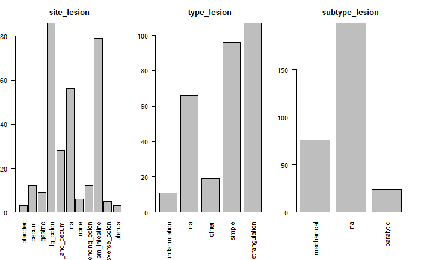

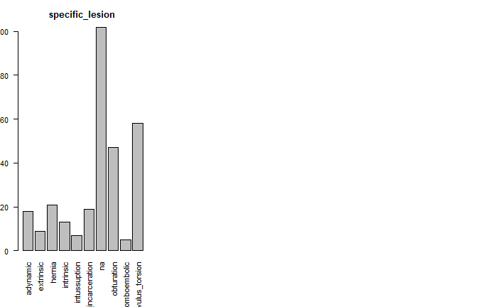

#### Massa de Treino/Teste e *imputation* dos dados discretos

Como dito anteriormente, vamos separar os dados em massas de treino e teste e depois aplicar um metódo de *imputation* nos dados discretos, que no nosso caso foi escolhido a média.

|  | surgery | age | rectal_temp | pulse | respiratory_rate | temp_of_extremities | peripheral_pulse | mucous_membrane | capillary_refill_time | pain | peristalsis | abdominal_distention | nasogastric_tube | nasogastric_reflux | rectal_exam_feces | abdomen | packed_cell_volume | total_protein | abdomo_appearance | outcome | surgical_lesion | site_lesion | type_lesion | subtype_lesion | specific_lesion |
| --- | --- | --- | --- | --- | --- | --- | --- | --- | --- | --- | --- | --- | --- | --- | --- | --- | --- | --- | --- | --- | --- | --- | --- | --- | --- |
| 1 | no | adult | 38.50000 | 66 | 28.00000 | cool | reduced | na | more_3_sec | extreme_pain | absent | severe | na | na | decreased | distend_large | 45.00000 | 8.40000 | na | died | no | none | inflammation | na | na |
| 2 | yes | adult | 39.20000 | 88 | 20.00000 | na | na | pale_cyanotic | less_3_sec | mild_pain | absent | slight | na | na | absent | other | 50.00000 | 85.00000 | cloudy | died | no | sm_intestine | strangulation | na | hernia |
| 3 | no | adult | 38.30000 | 40 | 24.00000 | normal | normal | pale_pink | less_3_sec | mild_pain | hypomotile | none | na | na | normal | normal | 33.00000 | 6.70000 | na | lived | no | na | na | na | na |
| 4 | yes | young | 39.10000 | 164 | 84.00000 | cold | normal | dark_cyanotic | more_3_sec | depressed | absent | severe | none | less_1_liter | decreased | na | 48.00000 | 7.20000 | serosanguious | died | yes | sm_intestine | strangulation | na | hernia |
| 5 | no | adult | 37.30000 | 104 | 35.00000 | na | na | dark_cyanotic | more_3_sec | na | na | na | na | na | na | na | 74.00000 | 7.40000 | na | died | no | lg_colon_and_cecum | inflammation | na | na |
| 6 | no | adult | 38.16862 | 72 | 30.46058 | warm | normal | pale_pink | less_3_sec | depressed | hypomotile | slight | slight | none | decreased | firm | 46.30741 | 24.27444 | na | lived | no | na | na | na | na |
| 7 | yes | adult | 37.90000 | 48 | 16.00000 | normal | normal | normal_pink | less_3_sec | mild_pain | hypomotile | moderate | none | none | decreased | distend_large | 37.00000 | 7.00000 | na | lived | yes | lg_colon | simple | paralytic | adynamic |
| 8 | yes | adult | 38.16862 | 60 | 30.46058 | cool | na | na | less_3_sec | na | absent | slight | slight | none | decreased | distend_small | 44.00000 | 8.30000 | na | died | yes | sm_intestine | strangulation | na | hernia |
| 9 | no | adult | 38.16862 | 80 | 36.00000 | cool | absent | pale_pink | less_3_sec | severe_pain | absent | severe | slight | none | decreased | distend_large | 38.00000 | 6.20000 | na | died | yes | lg_colon | strangulation | na | volvulus_torsion |
| 10 | no | young | 38.30000 | 90 | 30.46058 | normal | na | normal_pink | less_3_sec | extreme_pain | hypomotile | none | slight | none | decreased | na | 40.00000 | 6.20000 | clear | lived | no | na | na | na | na |

[output cut: 289 more lines]

|  | surgery | age | rectal_temp | pulse | respiratory_rate | temp_of_extremities | peripheral_pulse | mucous_membrane | capillary_refill_time | pain | peristalsis | abdominal_distention | nasogastric_tube | nasogastric_reflux | rectal_exam_feces | abdomen | packed_cell_volume | total_protein | abdomo_appearance | outcome | surgical_lesion | site_lesion | type_lesion | subtype_lesion | specific_lesion |
| --- | --- | --- | --- | --- | --- | --- | --- | --- | --- | --- | --- | --- | --- | --- | --- | --- | --- | --- | --- | --- | --- | --- | --- | --- | --- |
| 2 | no | adult | 37.30000 | 104 | 35.00000 | na | na | dark_cyanotic | more_3_sec | na | na | na | na | na | na | na | 74.00000 | 7.40000 | na | died | no | lg_colon_and_cecum | inflammation | na | na |
| 3 | no | adult | 39.10000 | 72 | 52.00000 | warm | na | bright_pink | less_3_sec | depressed | hypermotile | slight | none | none | absent | distend_small | 50.00000 | 7.80000 | na | lived | yes | sm_intestine | simple | mechanical | obturation |
| 4 | yes | adult | 37.20000 | 42 | 12.00000 | warm | normal | normal_pink | less_3_sec | mild_pain | hypomotile | moderate | significant | none | absent | distend_large | 46.30741 | 7.00000 | na | lived | no | lg_colon_and_cecum | simple | paralytic | adynamic |
| 5 | no | young | 38.00000 | 92 | 28.00000 | normal | normal | bright_pink | less_3_sec | alert | hypomotile | slight | significant | na | normal | normal | 37.00000 | 6.10000 | clear | died | no | na | na | na | na |
| 6 | yes | adult | 37.60000 | 64 | 21.00000 | normal | normal | bright_pink | less_3_sec | depressed | hypomotile | none | none | none | increased | distend_large | 40.00000 | 7.00000 | clear | lived | yes | lg_colon_and_cecum | strangulation | na | volvulus_torsion |
| 7 | yes | adult | 38.60000 | 42 | 34.00000 | warm | normal | pale_cyanotic | 3 | depressed | hypomotile | none | na | na | normal | na | 48.00000 | 7.20000 | na | lived | yes | lg_colon | simple | mechanical | obturation |
| 8 | yes | young | 38.30000 | 130 | 60.00000 | na | reduced | na | less_3_sec | depressed | absent | na | na | na | na | na | 50.00000 | 70.00000 | na | lived | yes | lg_colon | simple | mechanical | obturation |
| 9 | yes | adult | 37.80000 | 48 | 12.00000 | cool | normal | normal_pink | less_3_sec | na | hypomotile | slight | none | none | normal | firm | 37.00000 | 5.50000 | cloudy | lived | no | lg_colon_and_cecum | simple | paralytic | intrinsic |
| 10 | yes | adult | 38.16862 | 100 | 30.00000 | cool | reduced | pale_cyanotic | more_3_sec | extreme_pain | absent | severe | significant | more_1_liter | absent | distend_small | 52.00000 | 6.60000 | na | lived | yes | none | strangulation | na | na |
| 11 | no | adult | 38.16862 | 104 | 24.00000 | cold | reduced | pale_pink | more_3_sec | severe_pain | absent | moderate | na | more_1_liter | na | other | 73.00000 | 8.40000 | na | died | yes | retum_descending_colon | simple | mechanical | obturation |

[output cut: 79 more lines]

### Teste dos algoritmos

Depois de toda a preparação, finalmente testaremos alguns modelos preditivos. A princípio utilizaremos *Support Vector Machine*, *K-Nearest Neighbor*, e *Random Forest*.

#### 1. Algoritmo Random Forest

O algoritmo *Random Forest* utiliza uma estrutura de uma estrutra de árvore selecionando os atributos que mais geram ganho de informação sobre as classes a serem preditas. Nesse exemplo tivemos 1000 árvores e uma acurácia de 100%. Durante o processo foi feito o *tuning* dos parametros de quantidade de árvores e *splits* utilizando a bibiliote **caret**.

```
                          died      lived MeanDecreaseAccuracy MeanDecreaseGini
site_lesion          34.185023 12.9485124            35.292918        19.348406
type_lesion          19.619189 34.4913256            40.750274        31.939749
specific_lesion      15.282248 29.3236688            36.098750        19.403791
packed_cell_volume   13.816988 36.1345658            36.328907        18.183738
pain                 11.742698 18.4596292            20.886640        13.100259
mucous_membrane       7.433039  6.3881762             9.892464        11.192125
temp_of_extremities  18.201141  0.7629906            15.036023         8.558715
abdominal_distention 12.668332  1.3206504            10.748013         6.253402
pulse                21.300643 11.0308352            23.877722        15.536590
[1] 100

predictionsForest died lived
            died    36     0
            lived    0    53
```

#### 2. Algoritmo K-Nearest Neighbor

Para o algoritmo KNN, a classificação é uma função que mede a distancia do ponto a ser avalidado em relação aos pontos do conjuto de treino. Caso a distancia seja menor para alguma classe, escolhemos essa classe como a resposta da classificação. No exemplo, o conjunto de dados foi discretizados através de duas técnicas chamadas *dummy code* e *ordinal code*, também ativamos a opção de normalização de dados com um bom resultado na acurácia, 89%. Também foi alterada a quantidade *k* achando o valor ótimo de 3 vizinhos.

```
[1] 89.88764

KNN_model died lived
    died    29     2
    lived    7    51
```

#### 3. Support Vector Machine

O algoritmo *SVM* é uma abordagem que separa os dados utlizando um hiperplano em R<sup>n</sup>. Também utiliza-se um núcleo, que nada mais é que uma transformação linear entre dois espaços, esse núcleo é essencial pois introduz a não linearidade no modelo, aumentando a capacidade de abstração. No exemplo foi utilizado o núcleo polinomial ao invés do radial, aumentando a acurácia de 93% para 96%.

```
[1] 96.62921

predictionsSVM died lived
         died    33     0
         lived    3    53
```

#### Conclusão

Dos algoritmos testados a melhor performance foi do _Random Forest_com 100% ao contrário da pior performance, 89%, no *KNN*. Também foi obtido boa performance com *SVM* chegando a 96% de acerto. Acredito que poderia tratar melhor o *dataset*, como por exemplo, a remoção ou normalização de *outliers*. Também devido a natureza dos dados, o data imputation poderia ter sido feito através de regressão linear.